```python
import numpy as np
import pandas as pd
from sklearn import preprocessing
from sklearn.feature_extraction.text import CountVectorizer
import seaborn as sns
import nltk
```

# L&D: Introduction to NLP Modelling with a focus on document similarity

This L&D session will focus on some basic concepts surrounding NLP, specifically

- Word embeddings
- Document embeddings
- Metrics for different types of NLP embeddings
- Traditional document similarity
- Semantic document similarity

This notebook will cover general concept in NLP modelling using examples from the VET Streamlining Project. The data source used for the L&D is publically available and can be found on training.gov.au.

## How do machines understand text data?

### Word embeddings

To understand how we start modelling text and language, we first need a comprehensive understanding of how machines understand text data, that is, we need to understand *embeddings*. Embeddings are essentially representations of objects in a vector space, without going into too much algebra, **embeddings convert abstract objects into usable numeric vectors**. As an example, *word embedding* are vector representations of words, *sentence embeddings* of sentences, and *document embeddings* of documents. Embeddings aren't unique to natural language processing, we see them all across data science. We have can *geographic embeddings* e.g. a 1-0 coded vector of where your friend may possibly be on a grid or *image embedding* which are representations of an images as vectors or tensors.

Mathematically, the embeddings we'll consider are functions $f: X \to \mathbb{R}^n$ where $n$ differs by the type of embedding you choose and $X$ is usually a set of words.

### Examples of embeddings

Here we'll consider some simple examples of embeddings, in particular we will briefly look at

- One-hot embedding
- Embedding Layers
- Word2Vec embeddings
- GloVe embeddings
- Attention-based embeddings
  - BERT
  - GPT-2

#### Simple word embeddings

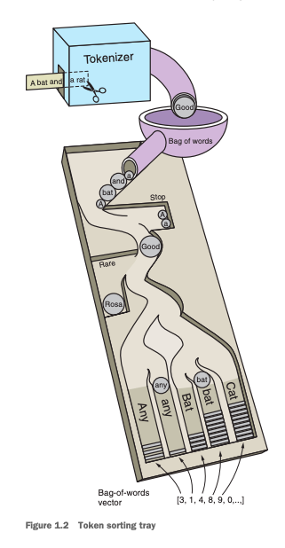

We'll use example of 3 words, "I", "like", and "cats". The simplest word embedding is a simple one-hot encoding, that is,

$I = [1,0,0]$

$like = [0,1,0]$

$cats = [0,0,1]$

```python
words = ["I", "like", "cats"]
pd.get_dummies(pd.Series(sum([tag.split(', ') for tag in words],[])))
```

|  | I | cats | like |
| --- | --- | --- | --- |
| 0 | 1 | 0 | 0 |
| 1 | 0 | 0 | 1 |
| 2 | 0 | 1 | 0 |

**Sentence Embeddings**

We can easily convert these embeddings into sentence embeddings by summing up the vectors for the words that make up a sentence. This type of aggregation of word embeddings into document embeddings is called "Bag of words". Here's an example

```python
documents = [
    "I like cats",
    "I do not like cats",
    "I wish I could speak french and german",
    "I like dogs"
]

cvec = CountVectorizer(token_pattern=r"\b\w+\b") #token pattern set since default remove the word "I"
vectors = cvec.fit_transform(documents).toarray()
pd.DataFrame(vectors, columns = cvec.get_feature_names())
```

|  | and | cats | could | do | dogs | french | german | i | like | not | speak | wish |
| --- | --- | --- | --- | --- | --- | --- | --- | --- | --- | --- | --- | --- |
| 0 | 0 | 1 | 0 | 0 | 0 | 0 | 0 | 1 | 1 | 0 | 0 | 0 |
| 1 | 0 | 1 | 0 | 1 | 0 | 0 | 0 | 1 | 1 | 1 | 0 | 0 |
| 2 | 1 | 0 | 1 | 0 | 0 | 1 | 1 | 2 | 0 | 0 | 1 | 1 |
| 3 | 0 | 0 | 0 | 0 | 1 | 0 | 0 | 1 | 1 | 0 | 0 | 0 |

#### Text processing

We see some obvious issues in the above representations, some main ones are

**Some words contain little information**

In our example, some of the words have relatively little information such as "I" and "and" these words are called stop words. These can be removed fairly in a fairly standard way.

**Similar words have different vector representations**

In our simple word embeddings, the word "study", "studies", "studying", "student" will be represented as different vectors, however they all have the same root.

Two simple ways of dealing with this is *lemmatisation* or *stemming*. Both are ways of obtaining the root word, the key difference is that a lemmatisation has context built in and will convert words to proper dictionary words while stemming doesn't.

$Original: study, studies, student, good, better, car, automobile$

$Lemmatised: study, study, study, good, good, car, car$

$Stemmed: study, studi, study, good, better, car, automobil$

**Word ordering**

Consider these two sentences sentence:

*I can't speak French, but I can speak English.*

*I can't speak English, but I can speak French.*

Under our simple sentence embedding technique these two sentences have the same representation however they have the opposing semantics.

**Some words contain more information than others**

When analysing sentences and documents, some words contain more information than others. One of the simplest ways of dealing with this is using a TF-IDF (Term Frequency, inverse document frequency). This weights words according to how often they appear within a sentence or document (term frequency), but also weighs words that occur rarely across sentences or documents higher.

$\text{tf-idf}(t, d) = \text{tf}(t, d) \times \text{idf}(t)$ where $\text{tf}(t,d)$ is the frequency of term $t$ in document $d$

$\text{idf}(t) = \log \frac{1 + n}{1 + df(t)} + 1$ where $\text{df}$ is the inverse document frequency

## Example from VET Streamlining

```python
from similarity_model import SimilarityModel
```

```python
model = SimilarityModel("preprocessed_units.csv")
```

**Data**

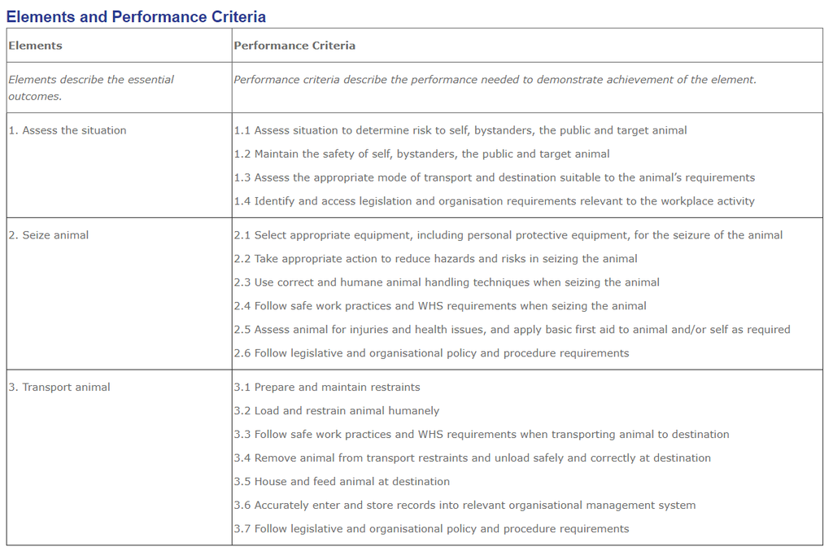

```python
# Text
unit_text = model.elements_performance_criteria_unstemmed[1]
print(unit_text)
```

```
assess the situation assess situation to determine risk to self bystanders the public and target animal maintain the safety of self bystanders the public and target animal assess the appropriate mode of transport and destination suitable to the animal s requirements identify and access legislation a…
```

```python
from nltk.tokenize import word_tokenize
# Should try adding to these.
from nltk.corpus import stopwords
from nltk.stem import WordNetLemmatizer
from nltk.stem import PorterStemmer

def data_preprocessing(unittext, stop_words=stopwords.words("english"), lemmatizer=WordNetLemmatizer() ):
    # We assume it's already lowercase and cleaned.

    tokens = nltk.word_tokenize(unittext)
    if "lemmatize" in dir(lemmatizer):
        unittext = [lemmatizer.lemmatize(word) for word in tokens]
        stop_words = [lemmatizer.lemmatize(word) for word in stop_words]
    elif "stem" in dir(lemmatizer):
        unittext = [lemmatizer.stem(word) for word in tokens]
        stop_words = [lemmatizer.stem(word) for word in stop_words]
    else:
        return("No method 'stem' or 'lemmatize' in lemmatizer")

    unittext = [word for word in unittext if word not in stop_words]

    unittext = " ".join(unittext)

    return unittext
```

**Lemmatisation**

```python
data_preprocessing(unit_text)
```

```
'ass situation ass situation determine risk self bystander public target animal maintain safety self bystander public target animal ass appropriate mode transport destination suitable animal requirement identify access legislation organisation requirement relevant workplace activity seize animal sel…
```

**Stemming**

```python
data_preprocessing(unit_text, lemmatizer=PorterStemmer())
```

```
'assess situat assess situat determin risk self bystand public target anim maintain safeti self bystand public target anim assess appropri mode transport destin suitabl anim requir identifi access legisl organis requir relev workplac activ seiz anim select appropri equip includ person protect equip …
```

```python
from sklearn.feature_extraction.text import TfidfVectorizer
from sklearn.metrics.pairwise import cosine_similarity

model.tfidf_vectorizer = TfidfVectorizer()
tfidf = model.tfidf_vectorizer.fit_transform(model.elements_performance_criteria)
```

```python
idf_weights = pd.DataFrame(model.tfidf_vectorizer.idf_, index = model.tfidf_vectorizer.get_feature_names(), columns = ["idf_weights"])
idf_weights.sort_values(by=['idf_weights']).head(10)
```

|  | idf_weights |
| --- | --- |
| requirement | 1.234173 |
| procedure | 1.368623 |
| identify | 1.400718 |
| appropriate | 1.449611 |
| required | 1.452995 |
| work | 1.511544 |
| equipment | 1.608543 |
| prepare | 1.631801 |
| ensure | 1.663717 |
| safety | 1.676468 |

```python
first_document_vector=tfidf[1]
feature_names = model.tfidf_vectorizer.get_feature_names()

#print the scores
df = pd.DataFrame(first_document_vector.T.todense(), index=feature_names, columns=["tfidf"])
df.sort_values(by=["tfidf"],ascending=False).head(10)
```

|  | tfidf |
| --- | --- |
| animal | 0.769396 |
| seizing | 0.317892 |
| destination | 0.237900 |
| bystander | 0.174071 |
| transport | 0.130563 |
| restraint | 0.127068 |
| self | 0.119752 |
| follow | 0.113572 |
| ass | 0.102412 |
| public | 0.097873 |

**Getting similarity scores from vectors**

After we have vector embeddings for our sentences we need a metric to compare these words. The only sensible metric for tf-idf vectors is cosine similarity.

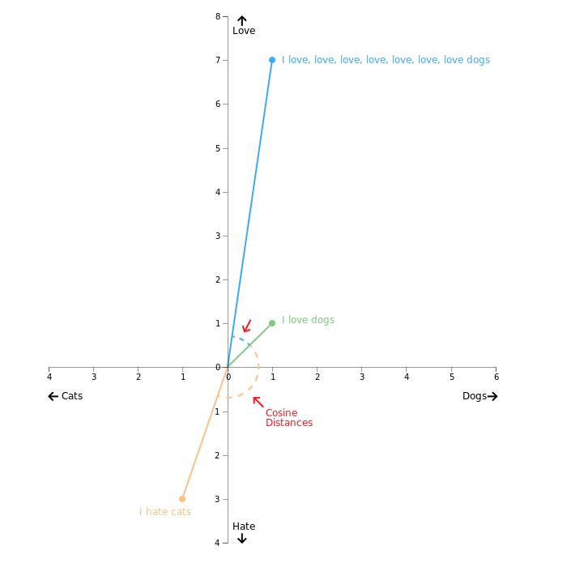

```python
# Note: these two are the same.
similarity_matrix = cosine_similarity(tfidf)
similarity_matrix2 = tfidf * tfidf.T
```

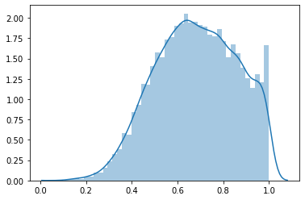

```python
max_similarity = np.amax(similarity_matrix - np.eye(similarity_matrix.shape[0]), 1)
sns.distplot(max_similarity)
```

```python
similarity_matrix - similarity_matrix2
```

```
matrix([[ 0.00000000e+00,  0.00000000e+00,  0.00000000e+00, ...,
          0.00000000e+00, -6.93889390e-18,  1.38777878e-17],
        [ 0.00000000e+00,  0.00000000e+00,  0.00000000e+00, ...,
          0.00000000e+00, -3.46944695e-18,  1.38777878e-17],
        [ 0.00000000e+00,  0.00000000e+00,  0.00000000e+00, ...,
          0.00000000e+00, -1.73472348e-18,  0.00000000e+00],
        ...,
        [ 0.00000000e+00,  0.00000000e+00,  0.00000000e+00, ...,
          0.00000000e+00, -5.55111512e-17,  5.55111512e-17],
        [-6.93889390e-18, -3.46944695e-18, -1.73472348e-18, ...,
         -5.55111512e-17, -5.55111512e-16, -5.55111512e-17],
        [ 1.38777878e-17,  1.38777878e-17,  0.00000000e+00, ...,
          5.55111512e-17, -5.55111512e-17,  4.44089210e-16]])
```

## Extending the model to address identified flaws

We've addressed some of our flaws however there's to main ones that we haven't addressed well

- Semantic meaning of words
- Words are used contextually

The reason why we started with word embeddings is because word embeddings play the most important role in similarity analysis (as well as alot of other types of NLP modelling). If we get better representation of word vectors, we get better comparisons between vectors.

- LDA embeddings
- Context-free embeddings
- Contextual embeddings

### LDA

We won't cover this in detail. General steps are

- Train an LDA model to distinguish between topics
- Use the model to obtain distributions for each focument
- Compare the topic distributions to each other using a variety of distance metrics:
  - Hellinger
  - Kullback-Leibler
  - Jaccard
- Compare document similarities using
  - Shannon-Jensen divergence
  - Kullback-Leibler

This didn't perform too well on our dataset

**Output from one topic cluster from LDA**

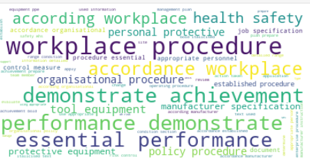

```python
from IPython.display import IFrame
IFrame("ldavis.html", width=1300, height=860) #ldavis_prepared.html
```

[interactive chart not shown]

### Word2Vec (Context-free learning models)

Learning based methods, in simple words, use neural networks to learn word representations. These have been studied in depth and are around a decade or two old.

Common context-free learning based word embeddings include

- Word2Vec (Google)
- GloVe (Stanford)
- fastText (Facebook)

They differ slightly so I'll explain the concept behind word2vec. There are three concepts behind word2vec

1. Learning based
   - A neural network (auto-encoder like) is used to learn word representation
2. Continuous bag of words (CBOW) or Skipgram
   - Theses are two architectures of how Word2Vec embeddings are learned
   - CBOW uses a window around a word to predict that word, Skipgram uses a word to predict the surrounding words
   - One of these assumptions is the distributional hypothesis, which is the idea that the meaning of a word can be understood from the words that tend to be near it. For example “bread” might tend to show up near “eat”, “bake”, “butter”, “toast”, etc., and this entourage gives a signal of what “bread” means.
3. One word - One embedding

With word2vec models we can do stuff like *king - man + woman = queen* with it's embeddings

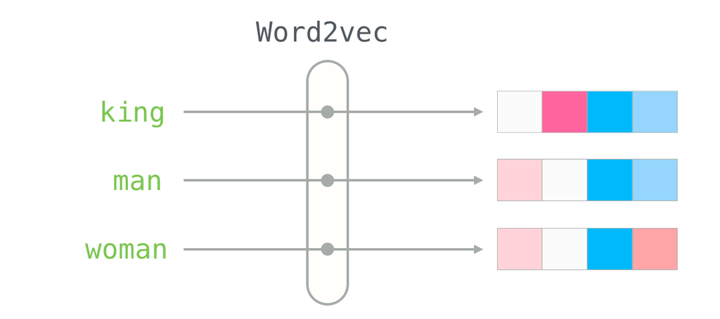

Document embeddings can be obtained through various means

- you can naively average or add up all word2vec vectors (Bag of words)
- you can include a document vector to be trained in the word2vec training process, this is called Distributed Memory - Paragraph Vector (PV-DM)
- you can train paragraph vectors by using them to predict words within the paragraph, this is called Distributed Bag of Words - Paragraph Vector (PV-DBOW)

```python
model.train_word2vec()
```

```python
from pyvis.network import Network

model.form_network_nodes(model.unitlist[1],"doc2vec",threshold=0.55,depth=1)
model.form_connections("doc2vec",threshold=0.6)
model.network.show("test.html")
```

[interactive chart not shown]

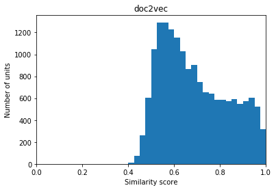

```python
model.plot_histogram("doc2vec",bins=40)
```

### Universal Sentence Encoder (Attenion-based learning models)

We wanted to explore the use of attention-based learning methods, these are only a few years old! However, we don't have the compute power to start using these models to their full potential, training them on VM's will also be very costly.

There is one key takeaway from attenion-based learning: **Embeddings for the same word changes based on the context it's used in**

The reason why these models are called "attenion" based models (after the paper "Attention is all you need") is because these models learn the relative importance of context words when creating word embeddings. That is, the model learns to "pay attention" to what words are important when understanding the word at hand.

A simple example can be seen by studying the sentence: *I used to live in France, I can speak fluent* ___________. A human can clearly pick up that the missing word is "French" by paying attention to the word "speak" and "France". These NLP models try and mimic this type of human understanding of words

**I've run out of time, so I won't explain the details**

Most attention-based embeddings used are pretrained from Google or Facebook (BeRT and ELMo) since they require many GPU's to train and large datasets. The one we use here is the Universal Sentence Encoder (USE) by Google, there are 4-5 versions of USE

```python
model.load_universal_sentence_encoder()
```

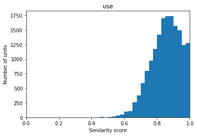

```python
model.plot_histogram("use", bins = 40, values = False)
```

```python
model.form_network_nodes(model.unitlist[1],"use",threshold=0.75,depth=1)
model.form_connections("use",threshold=0.8)
model.network.show("test.html")
```

[interactive chart not shown]

## Limitations and reflections our analysis

There is one main limitation that we haven't found any resources on how to resolve, that is, *similarity metrics* are hard to compare between different pairs of documents.

As a really simple VET related example,

Is "Sell to retail customer" and "Sell products and services" more similar to each other, or is, "Apply knowledge of WHS laws in the workplace" and "Apply knowledge of WHS legislation".

With most non-NLP similarity metrics it's quite easy to compare but for document similarity models, it's easy to compare the similarity of a range of documents to one specific document (e.g. Google does this every day), but it's hard to compare the similarity of different pairs of documents.

For our use case, a ranking of similarity is not enough and we unfortunately have to deal with this issue.

### Good news! We can steal someone elses word embedding model (sorta)

Word embeddings are hard to get right and **very computationally expensive** if you want to take into account all the factors that make language unpredictable. In comes transfer learning.

The idea behind transfer learning is that you take someone elses already learned word embeddings (e.g. Stanford, Google, Facebook models) and you can adapt those word embeddings to words that appear in your data i.e. you can essentially take an awesome model and customise if for your use case.

The caveat here is that transfer learning only works well if it's used for a supervised task. This is because you need some sort of a loss or scoring function to back-propogate the weights in order to "relearn" the word embedding model.